# Puppy Survey Response Summary

Tom Kremer

Last Updated: 2026-01-13

## Introductory Questions (All Respondents)

## S3

**S3: How old was your puppy when first brought home?**

4002 non-empty/NA responses out of 4002 possible responses ( 100 %)

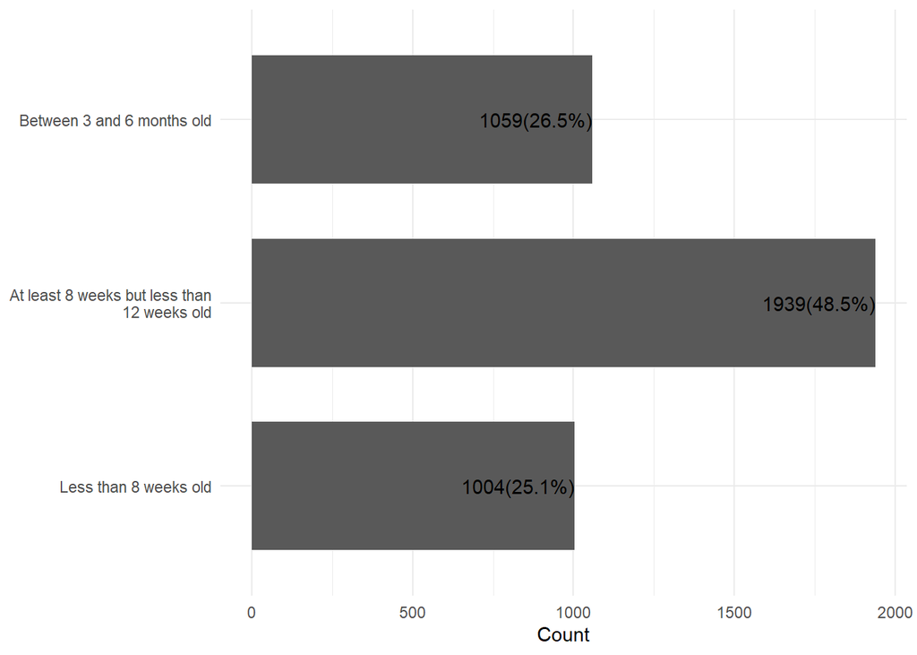

## S5

**S5: What is your age, in years?**

4002 non-empty/NA responses out of 4002 possible responses ( 100 %)

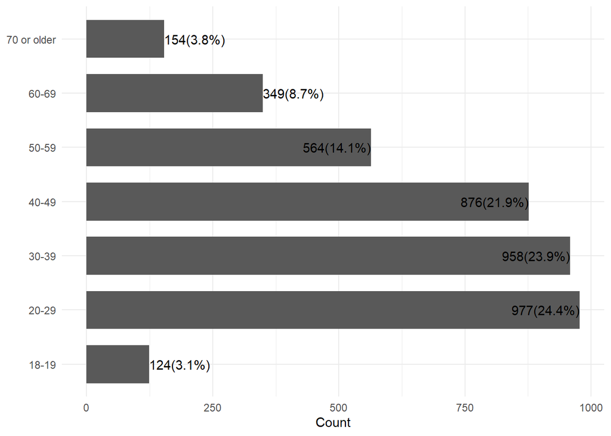

## Q1

**Q1: How old is your puppy now?**

4002 non-empty/NA responses out of 4002 possible responses ( 100 %)

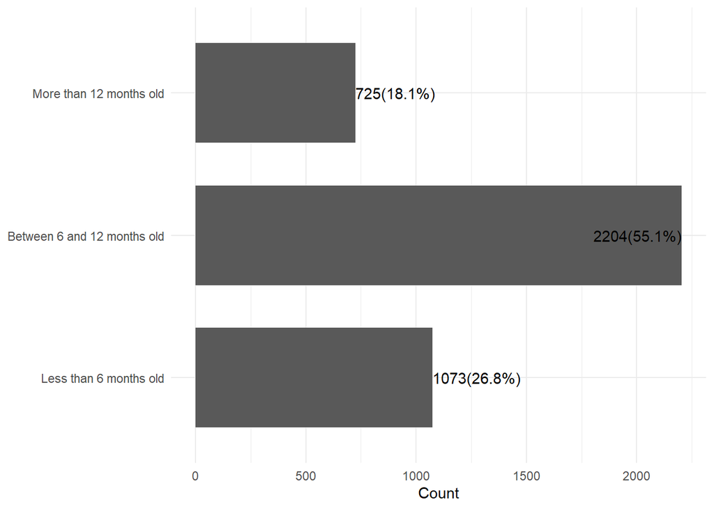

## Q2

**Q2: Are you the puppy’s first owner (besides the breeder, shop, rescue, or shelter where you got your puppy, if applicable)?**

4002 non-empty/NA responses out of 4002 possible responses ( 100 %)

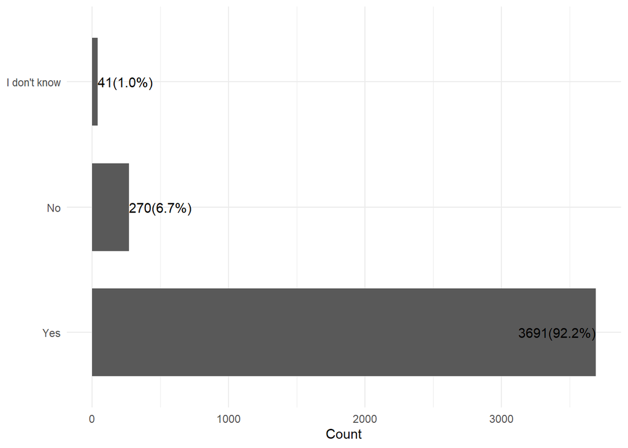

## Q3

**Q3: What is your puppy’s expected size when fully grown?**

4002 non-empty/NA responses out of 4002 possible responses ( 100 %)

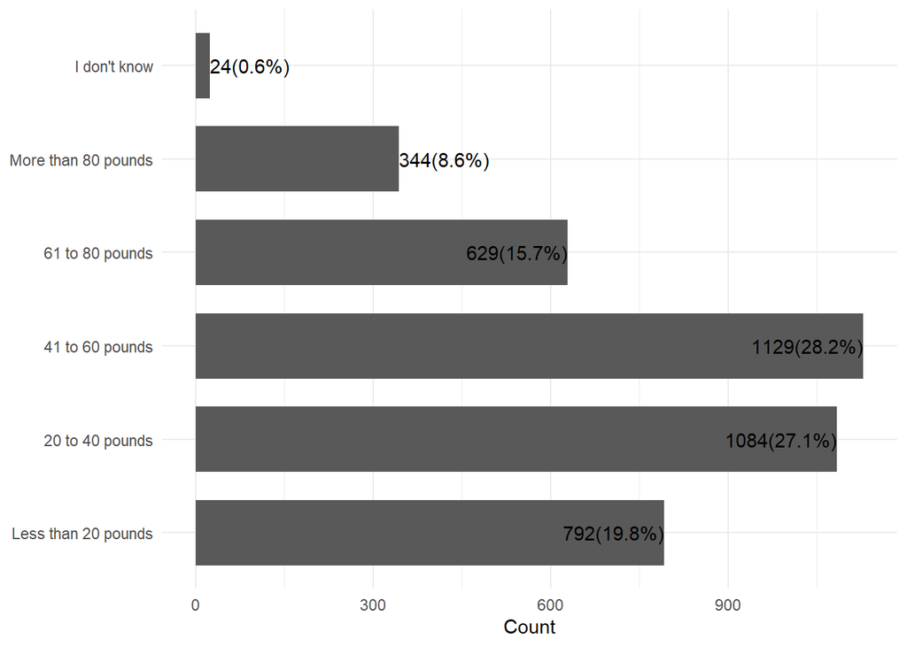

## Q5

**What information do you have on your puppy’s breed?**

9930 total non-empty/NA responses

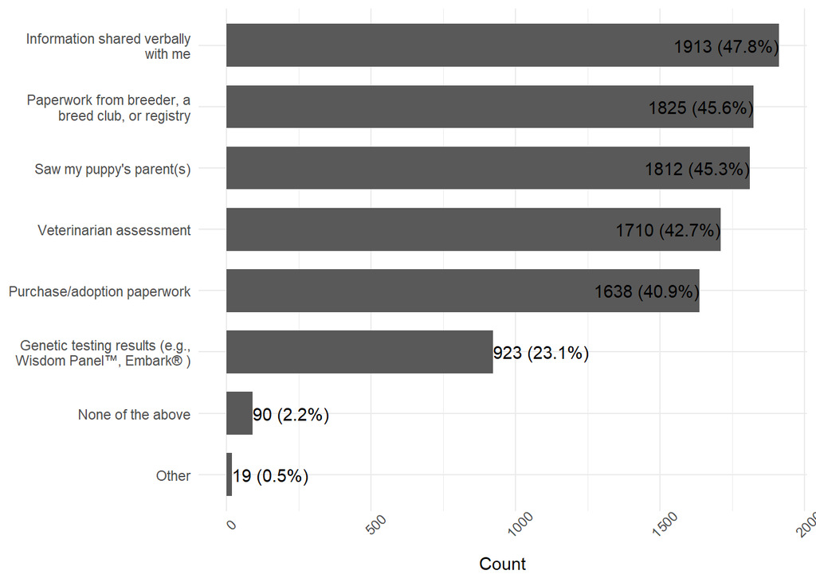

## Q4NEW_new (…)

**Q4: What best describes your puppy’s breed(s)?**

4002 non-empty/NA responses out of 4002 possible responses ( 100 %)

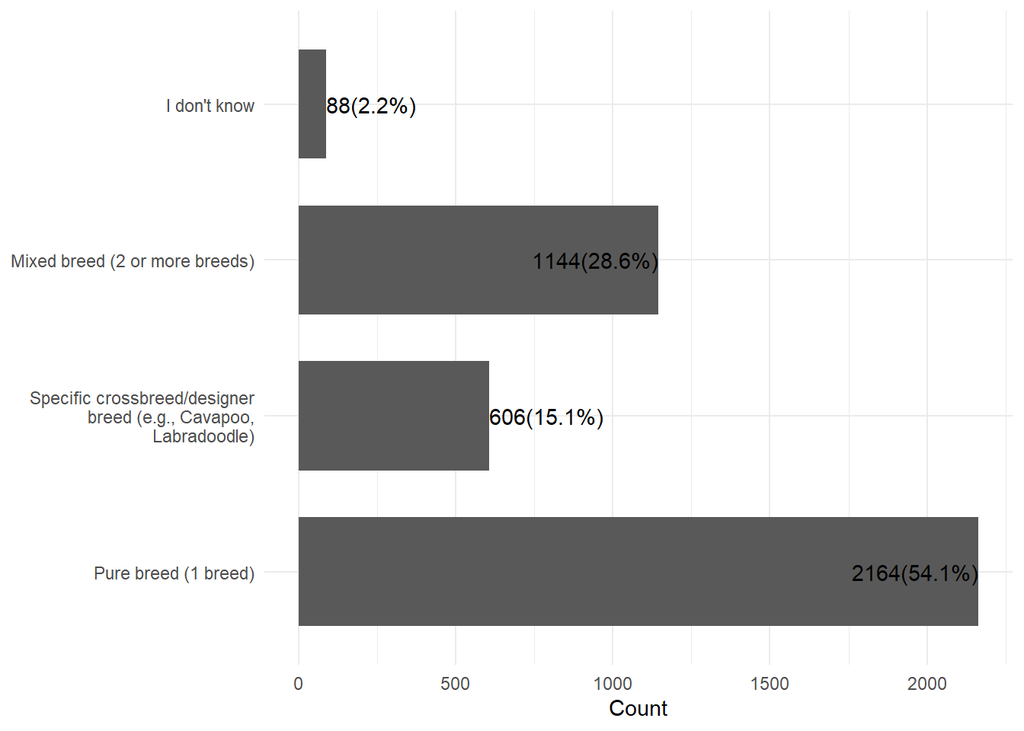

### > Q7

**Breed If answered pure breed**

2076 non-empty/NA responses out of 2164 possible responses ( 96 %); Showing top 10 values

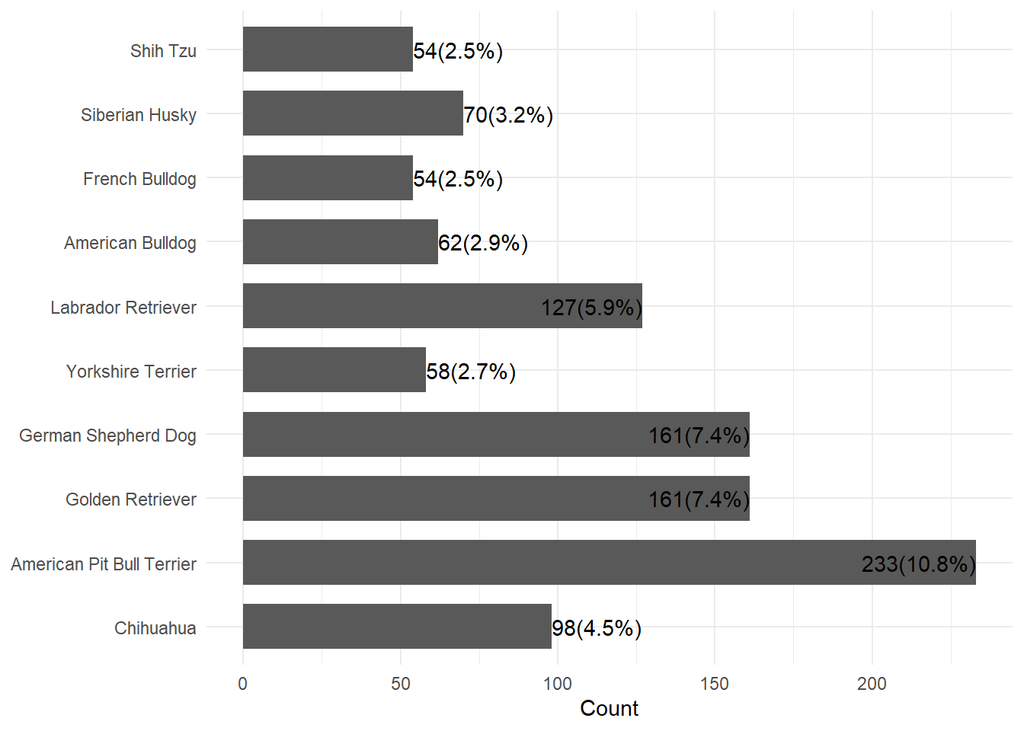

### > Q8

**Breed if answered specific crossbreed/designer**

528 non-empty/NA responses out of 606 possible responses ( 87 %); Showing top 10 values

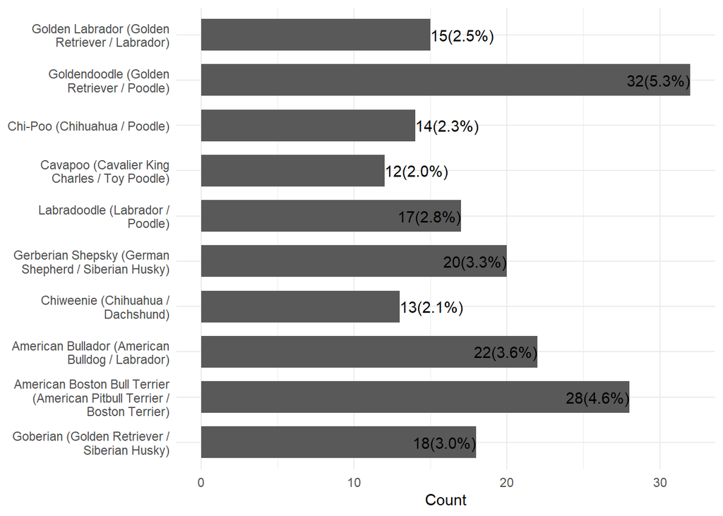

### > Q9 (…)

**Breed if answered mixed breed**

1009 non-empty/NA responses out of 1144 possible responses ( 88 %); Showing top 10 values

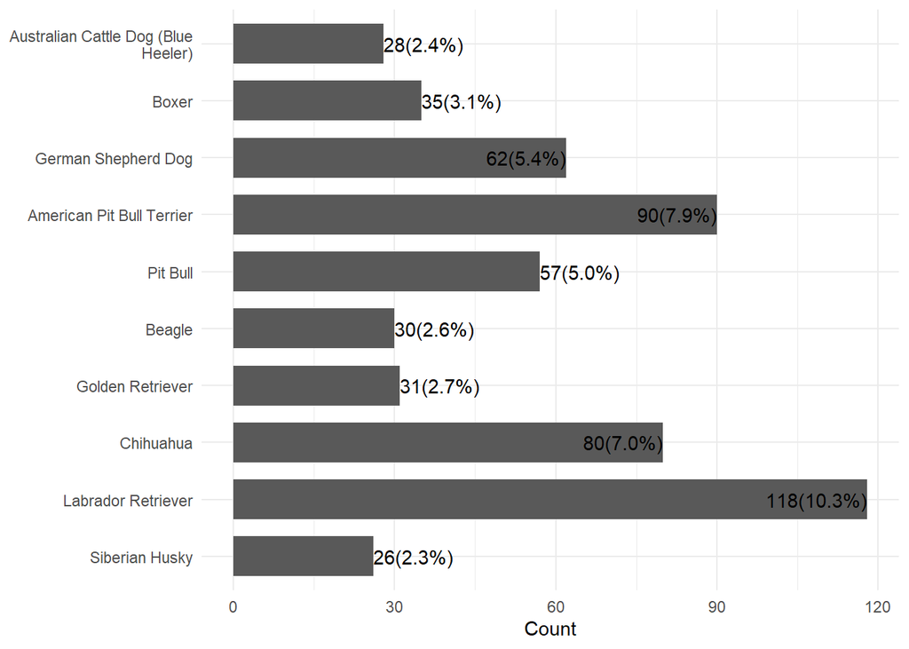

#### >> Q10

**Q10: Would you like to add a second breed for your puppy?**

1144 non-empty/NA responses out of 1144 possible responses ( 100 %)

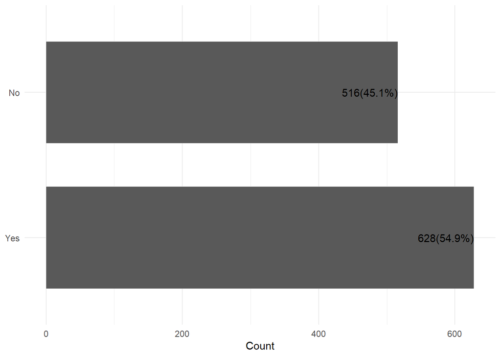

#### >> Q11

**Q11: Text - What is your puppy’s secondary breed? Please type the name in the text box below. It is okay if you are not certain of the breed; please provide your best guess. Select “I don’t know” only if you have no information on the breed.**

591 non-empty/NA responses out of 628 possible responses ( 94 %); Showing top 10 values

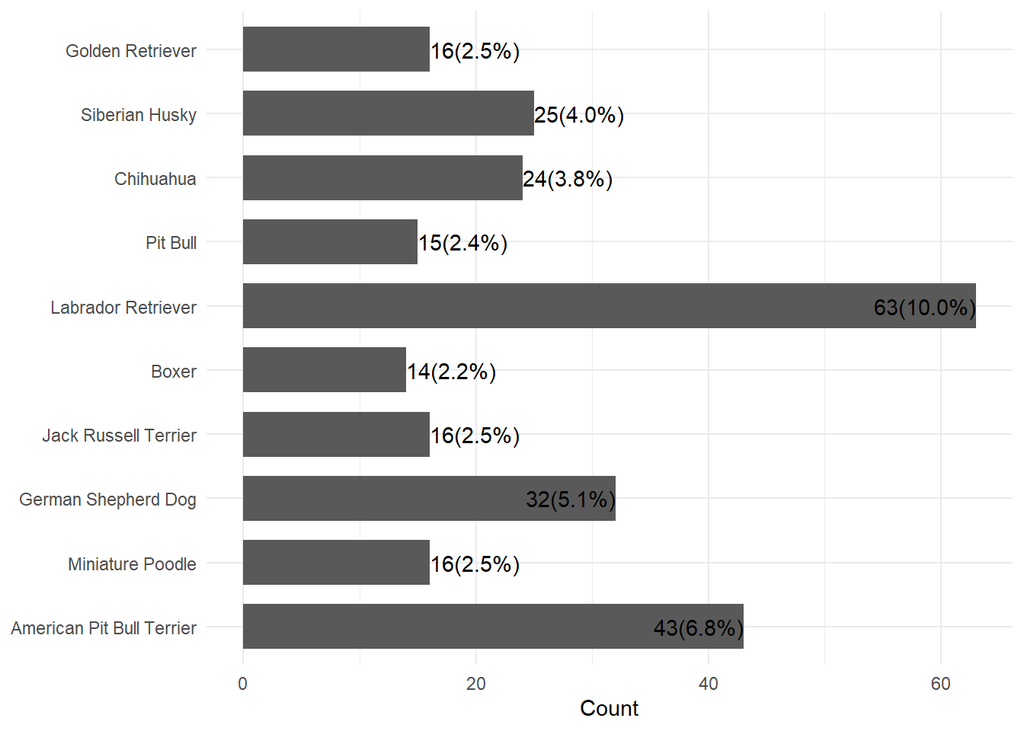

## Q12 (…)

**Q12: Is your puppy sterilized (spayed or neutered)?**

4002 non-empty/NA responses out of 4002 possible responses ( 100 %)

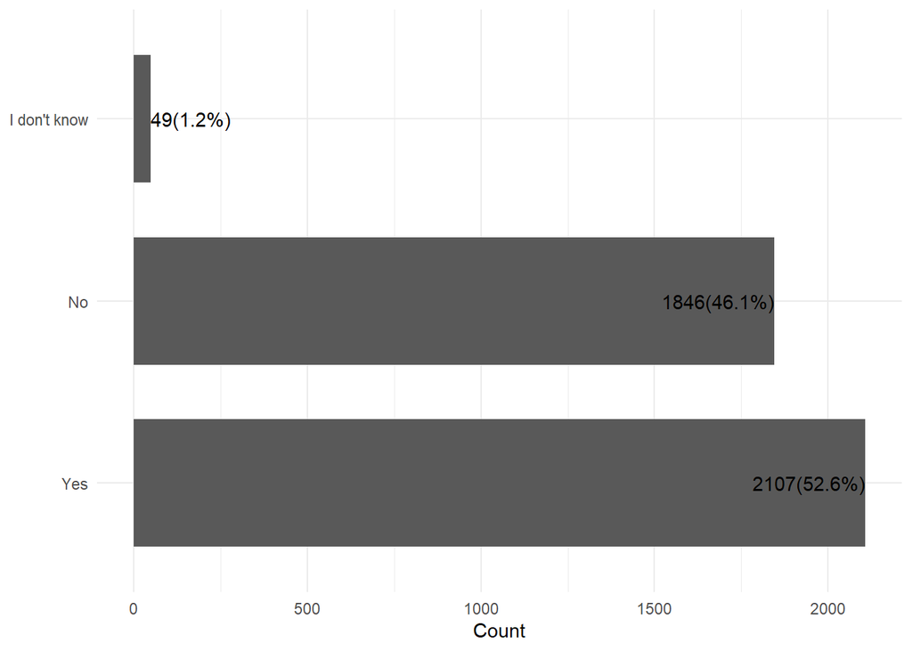

### > Q13 (…)

**Q13: Was your puppy sterilized before you brought them home?**

2107 non-empty/NA responses out of 2107 possible responses ( 100 %)

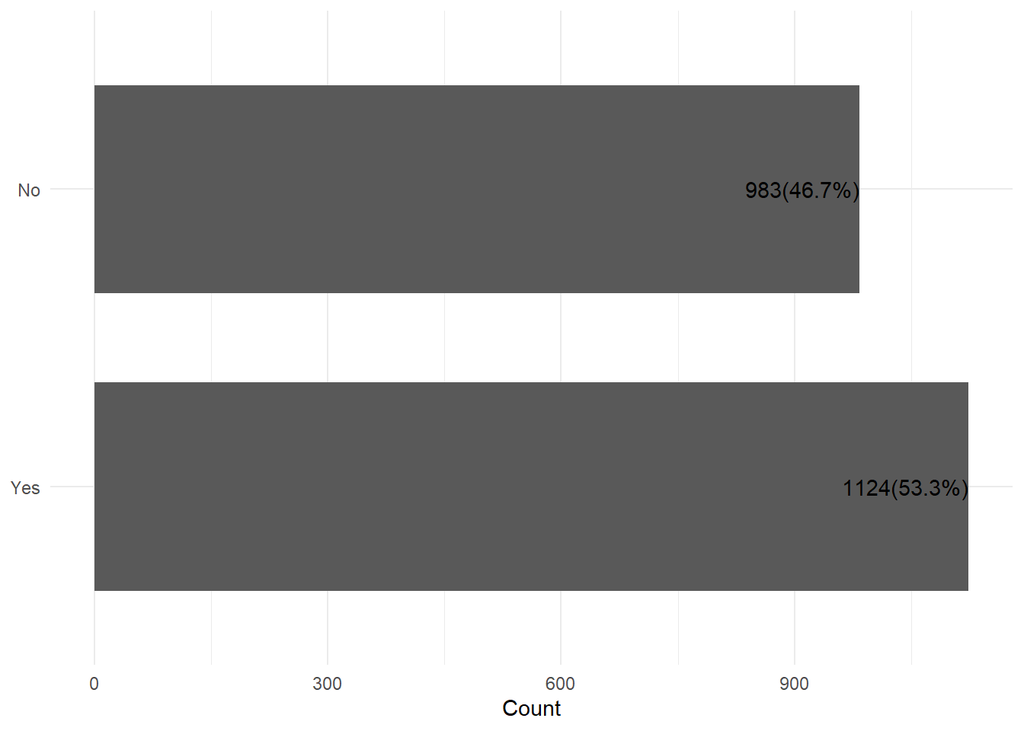

#### >> Q13a

**Q13a: At what age were they sterilized?**

983 non-empty/NA responses out of 983 possible responses ( 100 %)

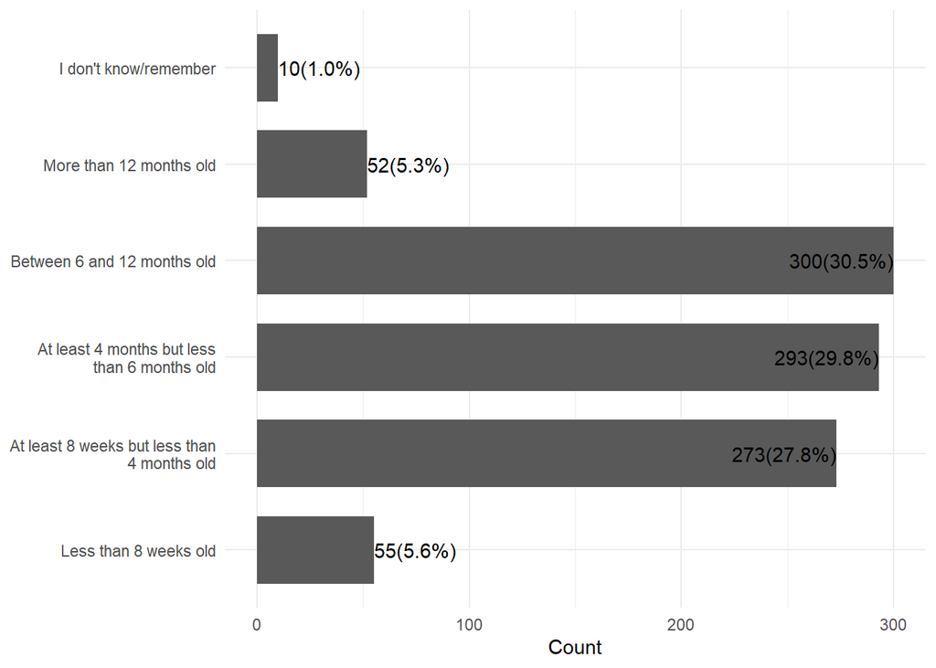

#### >> Q13b

**Q13b: Where did your puppy have their spay/neuter surgery?**

983 non-empty/NA responses out of 983 possible responses ( 100 %)

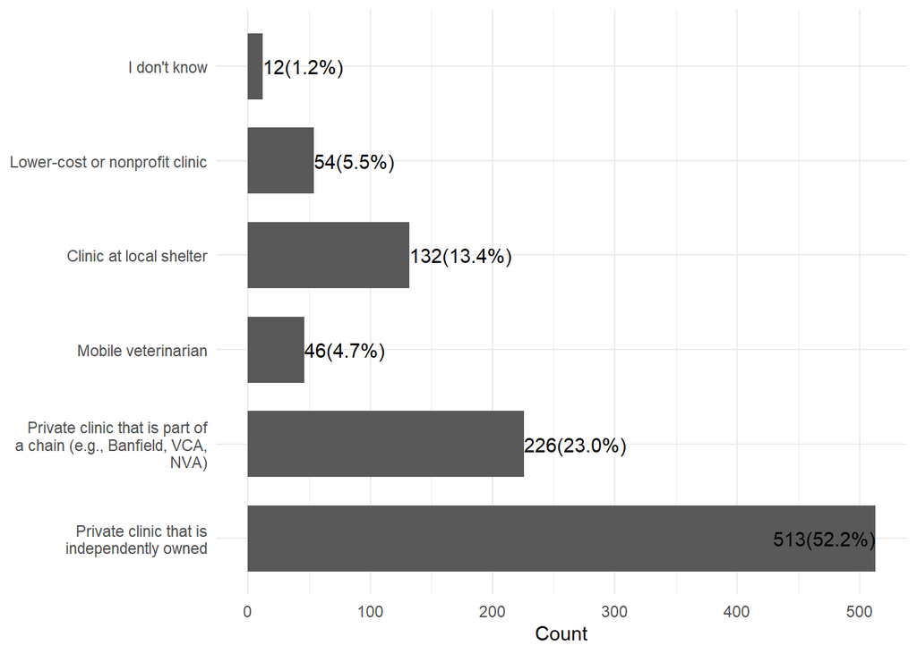

#### >> Q13c (…)

**Q13c: Has your puppy gone to a veterinarian since you got them other than for spay/neuter surgery?**

983 non-empty/NA responses out of 983 possible responses ( 100 %)

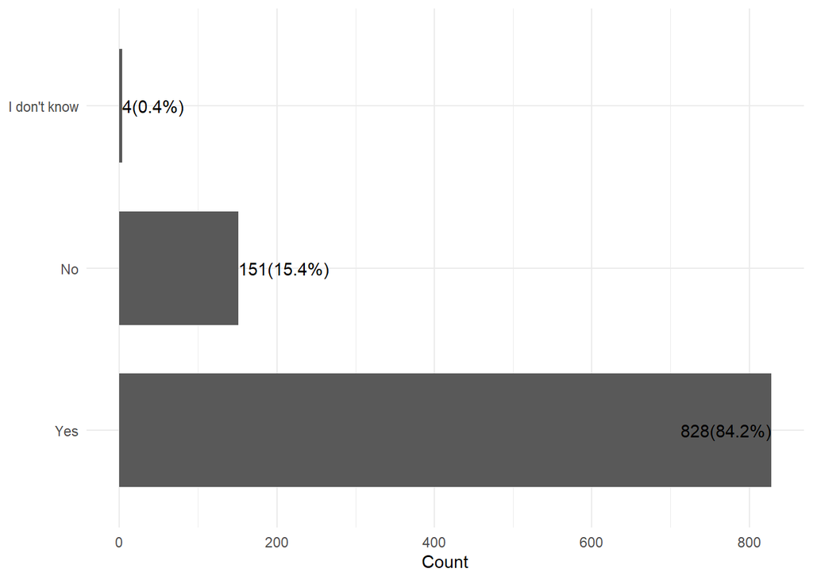

##### >>> Q13d

**Where has your puppy gone for other veterinary care?**

1101 total non-empty/NA responses

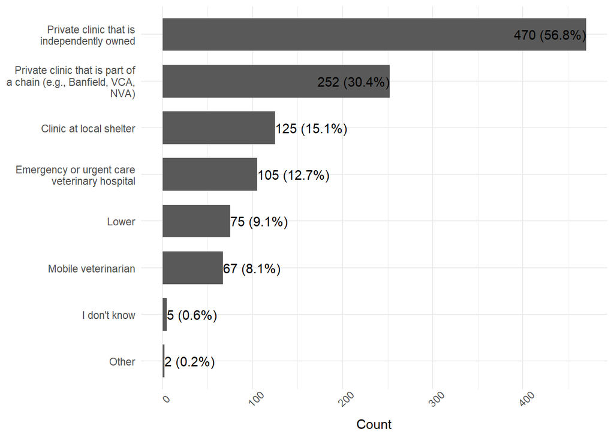

### > Q14

**Q14: Do you plan to breed your puppy in the future?**

1846 non-empty/NA responses out of 1895 possible responses ( 97 %)

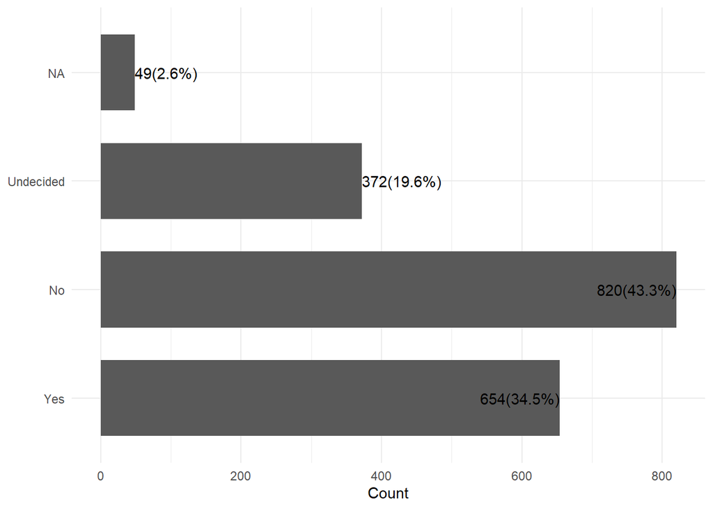

### > Q14a

**Q14a: Do you plan to sterilize your puppy in the future?**

1846 non-empty/NA responses out of 1895 possible responses ( 97 %)

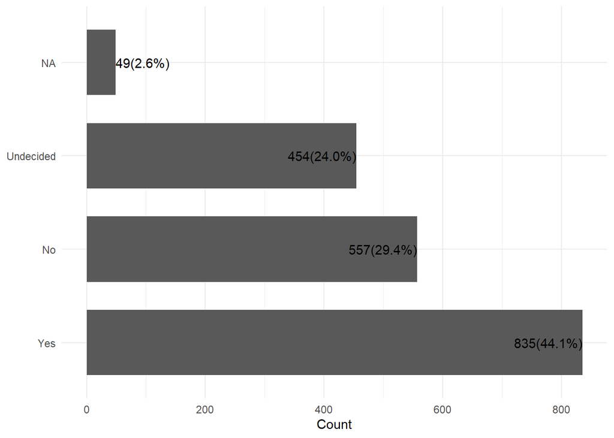

### > Q15

**Q15: Has your puppy gone to a veterinarian since you got them?**

3019 non-empty/NA responses out of 3019 possible responses ( 100 %)

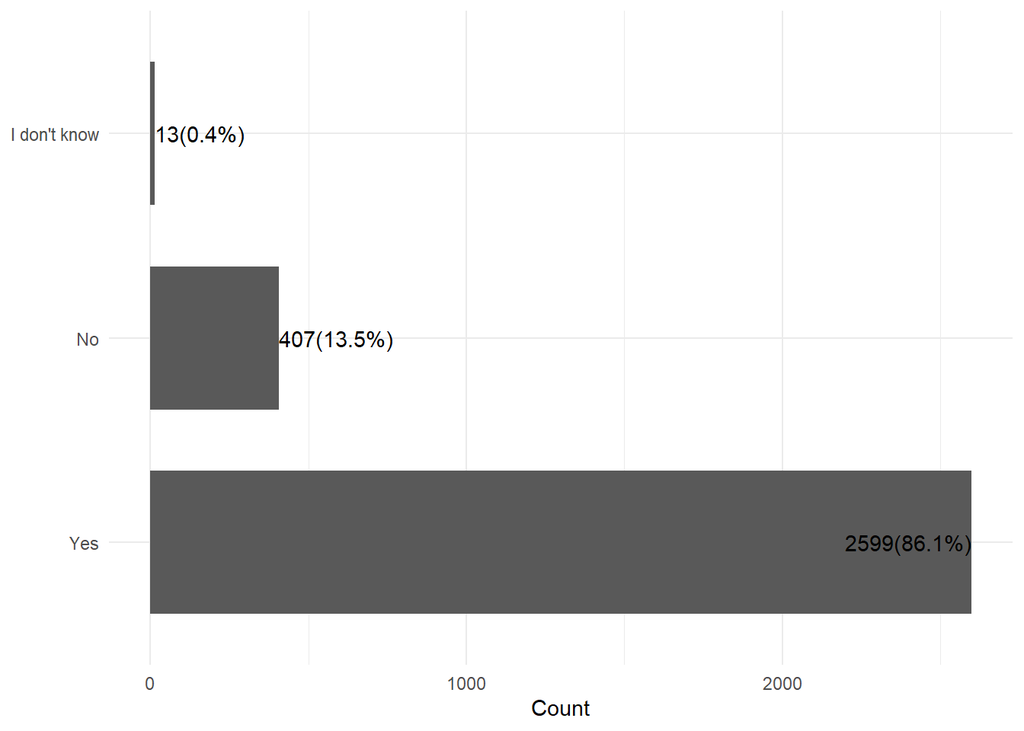

### > Q16

**Where has your puppy gone for veterinary care?**

3939 total non-empty/NA responses

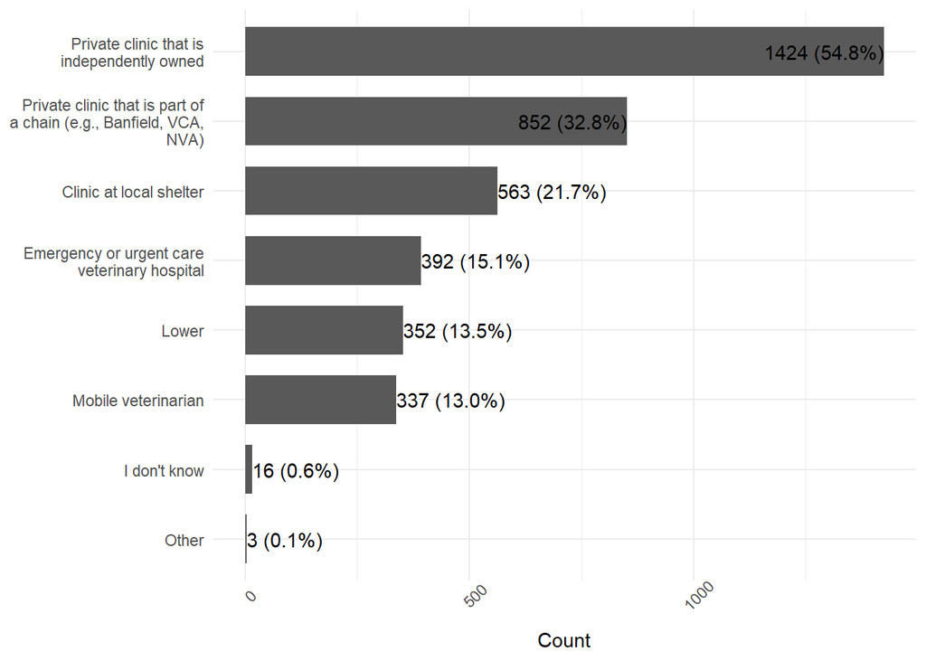

## Q17

**Q17: Before this puppy, were you ever a primary caretaker for a dog as an adult (when you were age 18 or older)?**

4002 non-empty/NA responses out of 4002 possible responses ( 100 %)

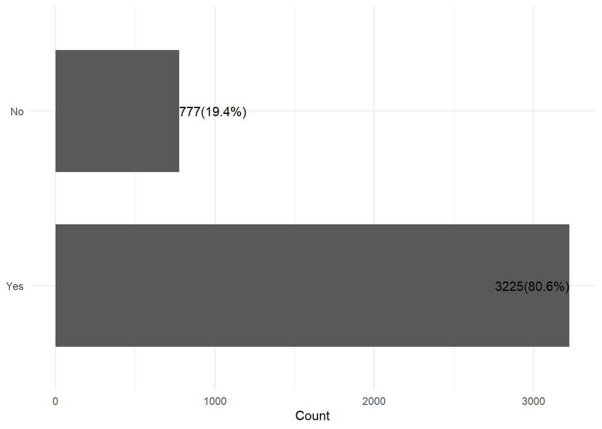

## Group A Only (…)

**Group A Only**

### > Timing and Availability

### > Q18 (…)

**Q18: How much time did you spend searching for a puppy?**

2001 non-empty/NA responses out of 2001 possible responses ( 100 %)

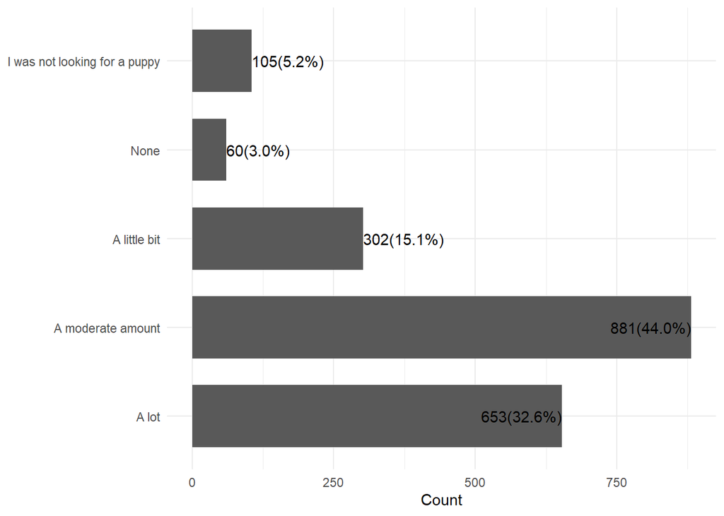

#### >> Q19

**You shared that you didn’t spend time searching for your puppy. Did any of the following apply to you getting your puppy?**

248 total non-empty/NA responses

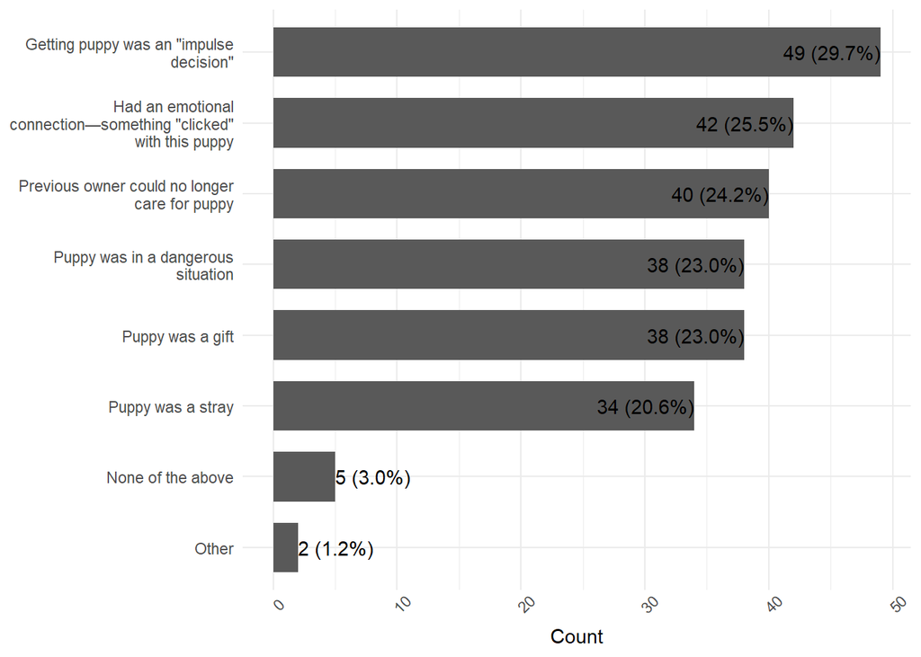

#### >> Q20

**Q20: How long was it from the time you started looking for a puppy to when you first brought your puppy home?**

1836 non-empty/NA responses out of 1836 possible responses ( 100 %)

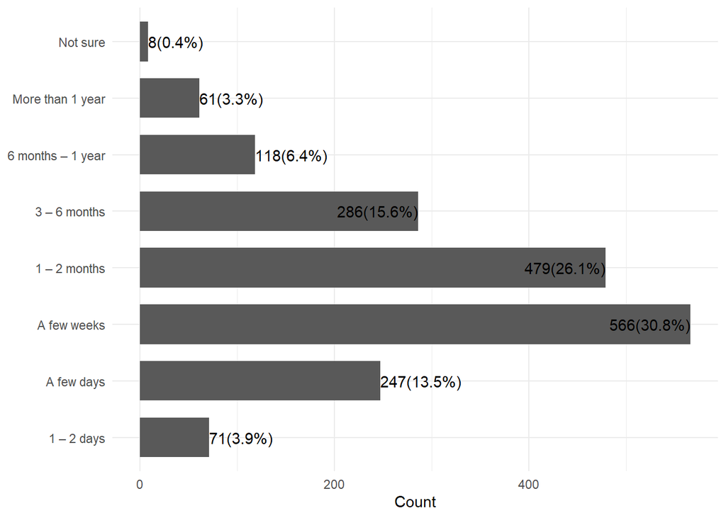

#### >> Q21 (…)

**Q21: How did this compare to the time you expected it would take?**

1836 non-empty/NA responses out of 1836 possible responses ( 100 %)

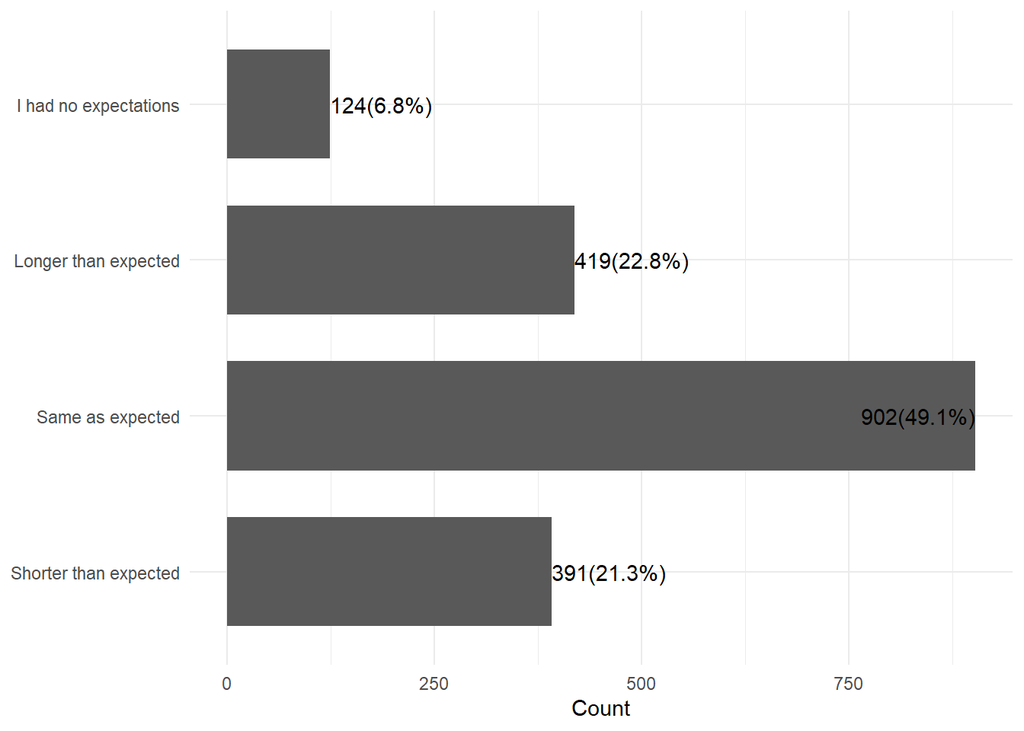

##### >>> Q22

**Why do you think it took as long as it did to get a puppy?**

899 total non-empty/NA responses

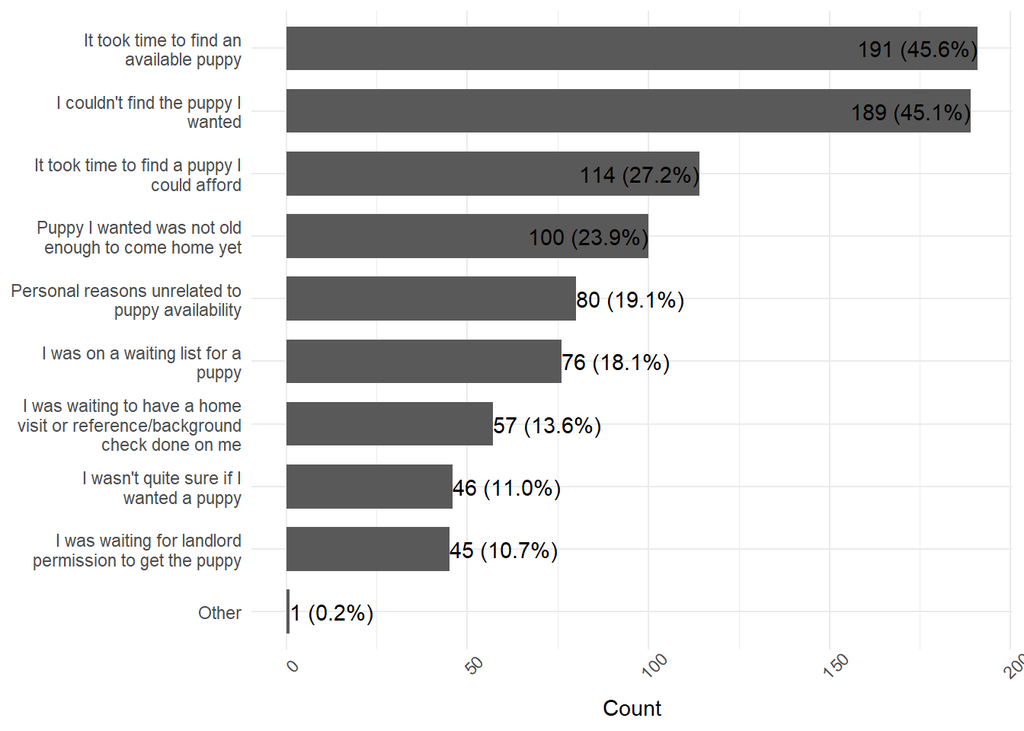

##### >>> Q23

**Why do you think you got your puppy faster than expected?**

642 total non-empty/NA responses

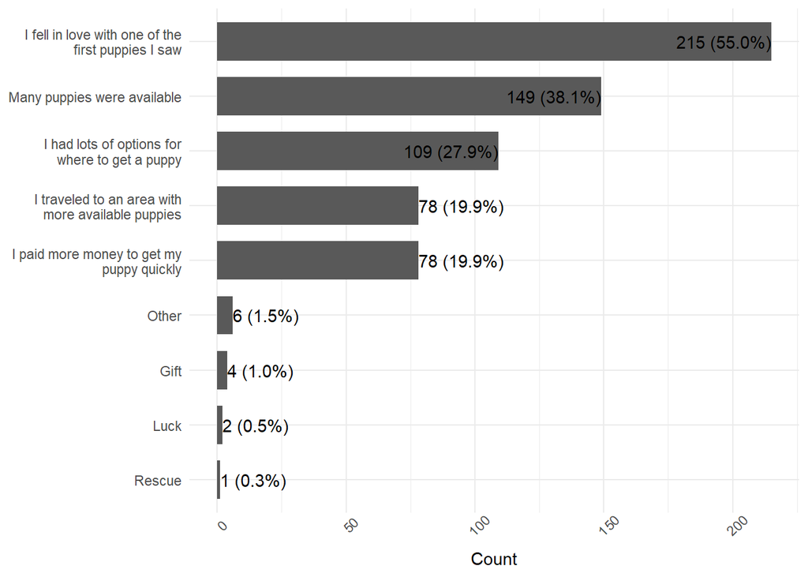

#### >> Motivation/Preferences for Puppy Features

#### >> Q24

**Q24: How closely did the puppy you got match what you were searching for?**

1896 non-empty/NA responses out of 1896 possible responses ( 100 %)

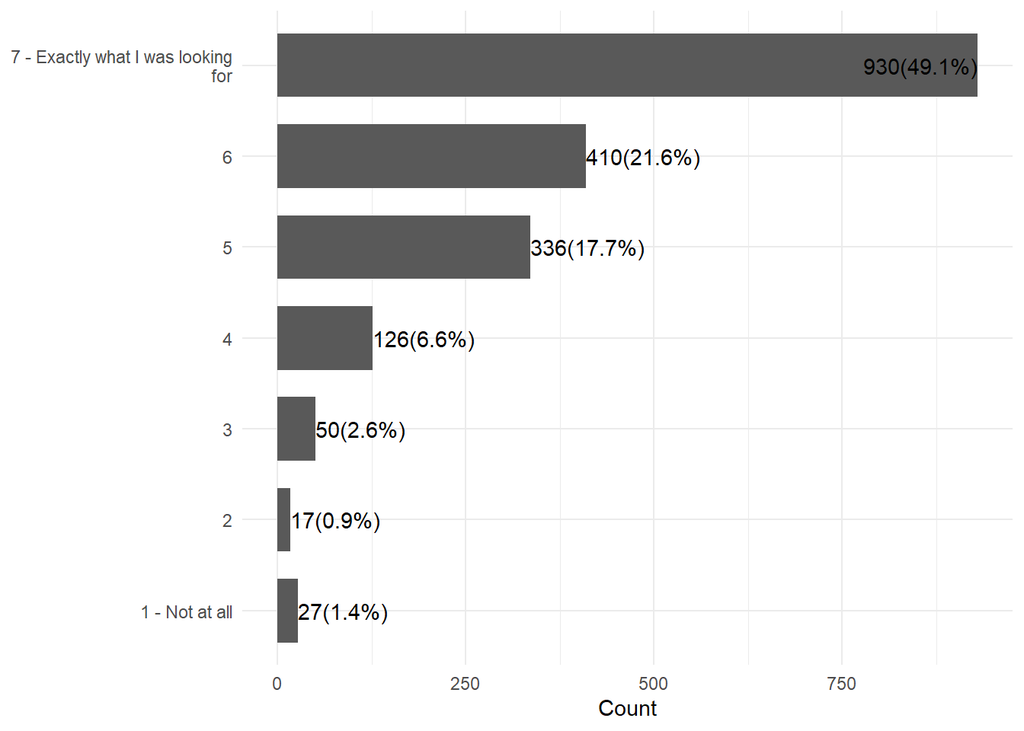